# Risk Factor Analysis

## Outcome Variable

**Outcome Variable:** ever_stunted

## Predictor Variables

**Intervention Variable:** mwtkg

**Adjustment Set:**

unadjusted

## Stratifying Variables

The analysis was stratified on these variable(s):

- agecat
- studyid
- country

## Data Summary

| agecat | studyid | country | A | n | nA | nAY0 | nAY1 |
| --- | --- | --- | --- | --- | --- | --- | --- |
| 3 months | ki0047075b-MAL-ED | BANGLADESH | >=57.5 | 254 | 51 | 40 | 11 |
| 3 months | ki0047075b-MAL-ED | BANGLADESH | <42.5 | 254 | 55 | 35 | 20 |
| 3 months | ki0047075b-MAL-ED | BANGLADESH | [42.5-50) | 254 | 89 | 60 | 29 |
| 3 months | ki0047075b-MAL-ED | BANGLADESH | [50-57.5) | 254 | 59 | 47 | 12 |
| 3 months | ki0047075b-MAL-ED | BRAZIL | >=57.5 | 221 | 144 | 122 | 22 |
| 3 months | ki0047075b-MAL-ED | BRAZIL | <42.5 | 221 | 14 | 10 | 4 |
| 3 months | ki0047075b-MAL-ED | BRAZIL | [42.5-50) | 221 | 19 | 16 | 3 |
| 3 months | ki0047075b-MAL-ED | BRAZIL | [50-57.5) | 221 | 44 | 39 | 5 |
| 3 months | ki0047075b-MAL-ED | INDIA | >=57.5 | 242 | 44 | 37 | 7 |
| 3 months | ki0047075b-MAL-ED | INDIA | <42.5 | 242 | 47 | 32 | 15 |
| 3 months | ki0047075b-MAL-ED | INDIA | [42.5-50) | 242 | 76 | 53 | 23 |
| 3 months | ki0047075b-MAL-ED | INDIA | [50-57.5) | 242 | 75 | 55 | 20 |
| 3 months | ki0047075b-MAL-ED | NEPAL | >=57.5 | 238 | 87 | 73 | 14 |
| 3 months | ki0047075b-MAL-ED | NEPAL | <42.5 | 238 | 2 | 2 | 0 |
| 3 months | ki0047075b-MAL-ED | NEPAL | [42.5-50) | 238 | 50 | 36 | 14 |
| 3 months | ki0047075b-MAL-ED | NEPAL | [50-57.5) | 238 | 99 | 90 | 9 |
| 3 months | ki0047075b-MAL-ED | PERU | >=57.5 | 290 | 104 | 76 | 28 |
| 3 months | ki0047075b-MAL-ED | PERU | <42.5 | 290 | 14 | 7 | 7 |
| 3 months | ki0047075b-MAL-ED | PERU | [42.5-50) | 290 | 57 | 33 | 24 |
| 3 months | ki0047075b-MAL-ED | PERU | [50-57.5) | 290 | 115 | 74 | 41 |
| 3 months | ki0047075b-MAL-ED | SOUTH AFRICA | >=57.5 | 270 | 194 | 147 | 47 |
| 3 months | ki0047075b-MAL-ED | SOUTH AFRICA | <42.5 | 270 | 3 | 0 | 3 |
| 3 months | ki0047075b-MAL-ED | SOUTH AFRICA | [42.5-50) | 270 | 16 | 11 | 5 |
| 3 months | ki0047075b-MAL-ED | SOUTH AFRICA | [50-57.5) | 270 | 57 | 40 | 17 |
| 3 months | ki0047075b-MAL-ED | TANZANIA, UNITED REPUBLIC OF | >=57.5 | 256 | 103 | 79 | 24 |
| 3 months | ki0047075b-MAL-ED | TANZANIA, UNITED REPUBLIC OF | <42.5 | 256 | 9 | 3 | 6 |
| 3 months | ki0047075b-MAL-ED | TANZANIA, UNITED REPUBLIC OF | [42.5-50) | 256 | 69 | 43 | 26 |
| 3 months | ki0047075b-MAL-ED | TANZANIA, UNITED REPUBLIC OF | [50-57.5) | 256 | 75 | 50 | 25 |
| 3 months | ki1017093-NIH-Birth | BANGLADESH | >=57.5 | 629 | 86 | 74 | 12 |
| 3 months | ki1017093-NIH-Birth | BANGLADESH | <42.5 | 629 | 174 | 117 | 57 |

[output cut: 226 more lines]

The following strata were considered:

- agecat: 12 months, studyid: ki0047075b-MAL-ED, country: BANGLADESH
- agecat: 12 months, studyid: ki0047075b-MAL-ED, country: BRAZIL
- agecat: 12 months, studyid: ki0047075b-MAL-ED, country: INDIA
- agecat: 12 months, studyid: ki0047075b-MAL-ED, country: NEPAL
- agecat: 12 months, studyid: ki0047075b-MAL-ED, country: PERU
- agecat: 12 months, studyid: ki0047075b-MAL-ED, country: SOUTH AFRICA
- agecat: 12 months, studyid: ki0047075b-MAL-ED, country: TANZANIA, UNITED REPUBLIC OF
- agecat: 12 months, studyid: ki1017093-NIH-Birth, country: BANGLADESH
- agecat: 12 months, studyid: ki1017093b-PROVIDE, country: BANGLADESH
- agecat: 12 months, studyid: ki1017093c-NIH-Crypto, country: BANGLADESH
- agecat: 12 months, studyid: ki1066203-TanzaniaChild2, country: TANZANIA, UNITED REPUBLIC OF
- agecat: 12 months, studyid: ki1126311-ZVITAMBO, country: ZIMBABWE
- agecat: 12 months, studyid: ki1148112-LCNI-5, country: MALAWI
- agecat: 18 months, studyid: ki0047075b-MAL-ED, country: BANGLADESH
- agecat: 18 months, studyid: ki0047075b-MAL-ED, country: BRAZIL
- agecat: 18 months, studyid: ki0047075b-MAL-ED, country: INDIA
- agecat: 18 months, studyid: ki0047075b-MAL-ED, country: NEPAL
- agecat: 18 months, studyid: ki0047075b-MAL-ED, country: PERU
- agecat: 18 months, studyid: ki0047075b-MAL-ED, country: SOUTH AFRICA
- agecat: 18 months, studyid: ki0047075b-MAL-ED, country: TANZANIA, UNITED REPUBLIC OF
- agecat: 18 months, studyid: ki1017093-NIH-Birth, country: BANGLADESH
- agecat: 18 months, studyid: ki1017093b-PROVIDE, country: BANGLADESH
- agecat: 18 months, studyid: ki1017093c-NIH-Crypto, country: BANGLADESH
- agecat: 18 months, studyid: ki1066203-TanzaniaChild2, country: TANZANIA, UNITED REPUBLIC OF
- agecat: 18 months, studyid: ki1126311-ZVITAMBO, country: ZIMBABWE
- agecat: 18 months, studyid: ki1148112-LCNI-5, country: MALAWI
- agecat: 24 months, studyid: ki0047075b-MAL-ED, country: BANGLADESH
- agecat: 24 months, studyid: ki0047075b-MAL-ED, country: BRAZIL
- agecat: 24 months, studyid: ki0047075b-MAL-ED, country: INDIA
- agecat: 24 months, studyid: ki0047075b-MAL-ED, country: NEPAL
- agecat: 24 months, studyid: ki0047075b-MAL-ED, country: PERU
- agecat: 24 months, studyid: ki0047075b-MAL-ED, country: SOUTH AFRICA
- agecat: 24 months, studyid: ki0047075b-MAL-ED, country: TANZANIA, UNITED REPUBLIC OF
- agecat: 24 months, studyid: ki1017093-NIH-Birth, country: BANGLADESH
- agecat: 24 months, studyid: ki1017093b-PROVIDE, country: BANGLADESH
- agecat: 24 months, studyid: ki1017093c-NIH-Crypto, country: BANGLADESH
- agecat: 24 months, studyid: ki1066203-TanzaniaChild2, country: TANZANIA, UNITED REPUBLIC OF
- agecat: 24 months, studyid: ki1126311-ZVITAMBO, country: ZIMBABWE
- agecat: 24 months, studyid: ki1148112-LCNI-5, country: MALAWI
- agecat: 3 months, studyid: ki0047075b-MAL-ED, country: BANGLADESH
- agecat: 3 months, studyid: ki0047075b-MAL-ED, country: BRAZIL
- agecat: 3 months, studyid: ki0047075b-MAL-ED, country: INDIA
- agecat: 3 months, studyid: ki0047075b-MAL-ED, country: NEPAL
- agecat: 3 months, studyid: ki0047075b-MAL-ED, country: PERU
- agecat: 3 months, studyid: ki0047075b-MAL-ED, country: SOUTH AFRICA
- agecat: 3 months, studyid: ki0047075b-MAL-ED, country: TANZANIA, UNITED REPUBLIC OF
- agecat: 3 months, studyid: ki1017093-NIH-Birth, country: BANGLADESH
- agecat: 3 months, studyid: ki1017093b-PROVIDE, country: BANGLADESH
- agecat: 3 months, studyid: ki1017093c-NIH-Crypto, country: BANGLADESH
- agecat: 3 months, studyid: ki1066203-TanzaniaChild2, country: TANZANIA, UNITED REPUBLIC OF
- agecat: 3 months, studyid: ki1126311-ZVITAMBO, country: ZIMBABWE
- agecat: 6 months, studyid: ki0047075b-MAL-ED, country: BANGLADESH
- agecat: 6 months, studyid: ki0047075b-MAL-ED, country: BRAZIL
- agecat: 6 months, studyid: ki0047075b-MAL-ED, country: INDIA
- agecat: 6 months, studyid: ki0047075b-MAL-ED, country: NEPAL
- agecat: 6 months, studyid: ki0047075b-MAL-ED, country: PERU
- agecat: 6 months, studyid: ki0047075b-MAL-ED, country: SOUTH AFRICA
- agecat: 6 months, studyid: ki0047075b-MAL-ED, country: TANZANIA, UNITED REPUBLIC OF
- agecat: 6 months, studyid: ki1017093-NIH-Birth, country: BANGLADESH
- agecat: 6 months, studyid: ki1017093b-PROVIDE, country: BANGLADESH
- agecat: 6 months, studyid: ki1017093c-NIH-Crypto, country: BANGLADESH
- agecat: 6 months, studyid: ki1066203-TanzaniaChild2, country: TANZANIA, UNITED REPUBLIC OF
- agecat: 6 months, studyid: ki1126311-ZVITAMBO, country: ZIMBABWE
- agecat: 6 months, studyid: ki1148112-LCNI-5, country: MALAWI

### Dropped Strata

Some strata were dropped due to rare outcomes:

- agecat: 3 months, studyid: ki0047075b-MAL-ED, country: BRAZIL
- agecat: 3 months, studyid: ki0047075b-MAL-ED, country: NEPAL
- agecat: 3 months, studyid: ki0047075b-MAL-ED, country: SOUTH AFRICA
- agecat: 3 months, studyid: ki0047075b-MAL-ED, country: TANZANIA, UNITED REPUBLIC OF
- agecat: 6 months, studyid: ki0047075b-MAL-ED, country: BRAZIL
- agecat: 6 months, studyid: ki0047075b-MAL-ED, country: NEPAL
- agecat: 6 months, studyid: ki0047075b-MAL-ED, country: SOUTH AFRICA
- agecat: 6 months, studyid: ki0047075b-MAL-ED, country: TANZANIA, UNITED REPUBLIC OF
- agecat: 12 months, studyid: ki0047075b-MAL-ED, country: BRAZIL
- agecat: 12 months, studyid: ki0047075b-MAL-ED, country: NEPAL
- agecat: 12 months, studyid: ki0047075b-MAL-ED, country: PERU
- agecat: 12 months, studyid: ki0047075b-MAL-ED, country: SOUTH AFRICA
- agecat: 12 months, studyid: ki0047075b-MAL-ED, country: TANZANIA, UNITED REPUBLIC OF
- agecat: 18 months, studyid: ki0047075b-MAL-ED, country: BRAZIL
- agecat: 18 months, studyid: ki0047075b-MAL-ED, country: NEPAL
- agecat: 18 months, studyid: ki0047075b-MAL-ED, country: PERU
- agecat: 18 months, studyid: ki0047075b-MAL-ED, country: SOUTH AFRICA
- agecat: 18 months, studyid: ki0047075b-MAL-ED, country: TANZANIA, UNITED REPUBLIC OF
- agecat: 24 months, studyid: ki0047075b-MAL-ED, country: BRAZIL
- agecat: 24 months, studyid: ki0047075b-MAL-ED, country: NEPAL
- agecat: 24 months, studyid: ki0047075b-MAL-ED, country: PERU
- agecat: 24 months, studyid: ki0047075b-MAL-ED, country: SOUTH AFRICA
- agecat: 24 months, studyid: ki0047075b-MAL-ED, country: TANZANIA, UNITED REPUBLIC OF
- agecat: 24 months, studyid: ki1066203-TanzaniaChild2, country: TANZANIA, UNITED REPUBLIC OF

## Methods Detail

We’re interested in the causal parameters $E[Y_a]$ for all values of $a \in \mathcal{A}$. These parameters represent the mean outcome if, possibly contrary to fact, we intervened to set all units to have $A=a$. Under the randomization and positivity assumptions, these are identified by the statistical parameters $\psi_a=E_W[E_{Y|A,W}(Y|A=a,W)]$. In addition, we’re interested in the mean of $Y$, $E[Y]$ under no intervention (the observed mean). We will estimate these parameters by using SuperLearner to fit the relevant likelihood factors – $E_{Y|A,W}(Y|A=a,W)$ and $p(A=a|W)$, and then updating our likelihood fit using a joint TMLE.

For unadjusted analyses ($W=\{\}$), initial likelihoods were estimated using Lrnr_glm to estimate the simple $E(Y|A)$ and Lrnr_mean to estimate $p(A)$. For adjusted analyses, a small library containing Lrnr_glmnet, Lrnr_xgboost, and Lrnr_mean was used.

Having estimated these parameters, we will then use the delta method to estimate relative risks and attributable risks relative to a prespecified baseline level of $A$.

# Results Detail

## Results Plots

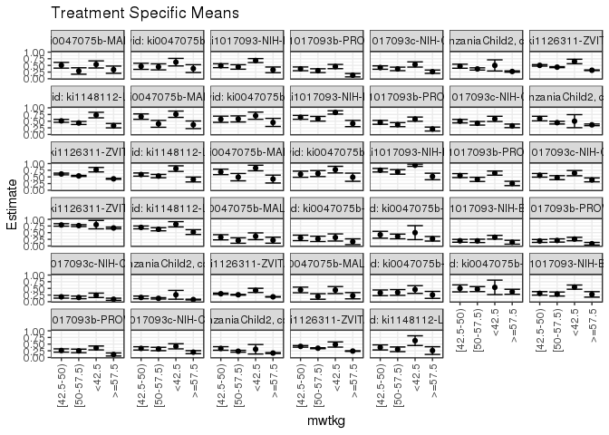

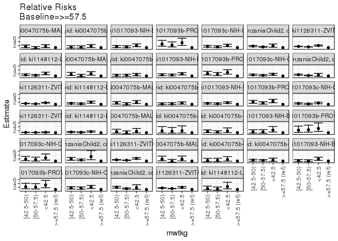

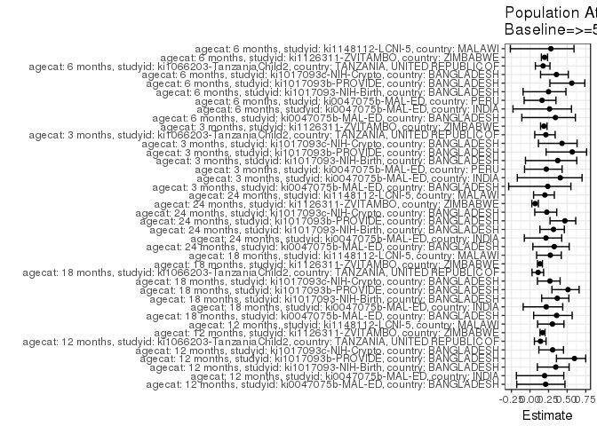

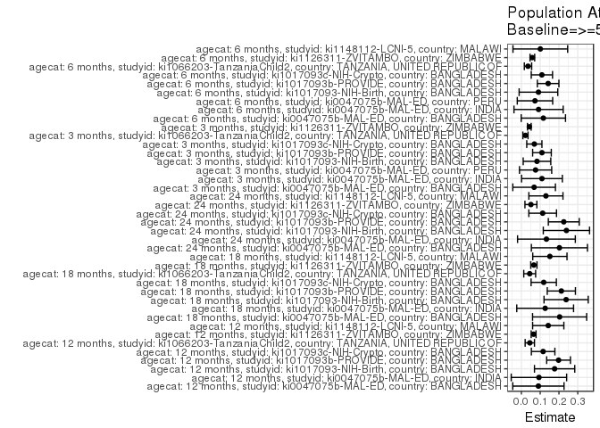

## Results Table

### Parameter: TSM

| agecat | studyid | country | intervention_level | baseline_level | estimate | ci_lower | ci_upper |
| --- | --- | --- | --- | --- | --- | --- | --- |
| 3 months | ki0047075b-MAL-ED | BANGLADESH | >=57.5 | NA | 0.2156863 | 0.1025828 | 0.3287897 |
| 3 months | ki0047075b-MAL-ED | BANGLADESH | <42.5 | NA | 0.3636364 | 0.2362539 | 0.4910188 |
| 3 months | ki0047075b-MAL-ED | BANGLADESH | [42.5-50) | NA | 0.3258427 | 0.2282776 | 0.4234078 |
| 3 months | ki0047075b-MAL-ED | BANGLADESH | [50-57.5) | NA | 0.2033898 | 0.1004778 | 0.3063019 |
| 3 months | ki0047075b-MAL-ED | INDIA | >=57.5 | NA | 0.1590909 | 0.0507935 | 0.2673883 |
| 3 months | ki0047075b-MAL-ED | INDIA | <42.5 | NA | 0.3191489 | 0.1856059 | 0.4526919 |
| 3 months | ki0047075b-MAL-ED | INDIA | [42.5-50) | NA | 0.3026316 | 0.1991344 | 0.4061288 |
| 3 months | ki0047075b-MAL-ED | INDIA | [50-57.5) | NA | 0.2666667 | 0.1663780 | 0.3669553 |
| 3 months | ki0047075b-MAL-ED | PERU | >=57.5 | NA | 0.2692308 | 0.1838355 | 0.3546261 |
| 3 months | ki0047075b-MAL-ED | PERU | <42.5 | NA | 0.5000000 | 0.2376361 | 0.7623639 |
| 3 months | ki0047075b-MAL-ED | PERU | [42.5-50) | NA | 0.4210526 | 0.2926575 | 0.5494477 |
| 3 months | ki0047075b-MAL-ED | PERU | [50-57.5) | NA | 0.3565217 | 0.2688299 | 0.4442136 |
| 3 months | ki1017093-NIH-Birth | BANGLADESH | >=57.5 | NA | 0.1395349 | 0.0662436 | 0.2128262 |
| 3 months | ki1017093-NIH-Birth | BANGLADESH | <42.5 | NA | 0.3275862 | 0.2577951 | 0.3973773 |
| 3 months | ki1017093-NIH-Birth | BANGLADESH | [42.5-50) | NA | 0.1935484 | 0.1409409 | 0.2461559 |
| 3 months | ki1017093-NIH-Birth | BANGLADESH | [50-57.5) | NA | 0.1907895 | 0.1282751 | 0.2533038 |
| 3 months | ki1017093b-PROVIDE | BANGLADESH | >=57.5 | NA | 0.0833333 | 0.0338456 | 0.1328210 |
| 3 months | ki1017093b-PROVIDE | BANGLADESH | <42.5 | NA | 0.2598870 | 0.1952282 | 0.3245458 |
| 3 months | ki1017093b-PROVIDE | BANGLADESH | [42.5-50) | NA | 0.1881188 | 0.1341852 | 0.2420524 |
| 3 months | ki1017093b-PROVIDE | BANGLADESH | [50-57.5) | NA | 0.2058824 | 0.1450548 | 0.2667099 |
| 3 months | ki1017093c-NIH-Crypto | BANGLADESH | >=57.5 | NA | 0.0913706 | 0.0511082 | 0.1316329 |
| 3 months | ki1017093c-NIH-Crypto | BANGLADESH | <42.5 | NA | 0.2403846 | 0.1582040 | 0.3225652 |
| 3 months | ki1017093c-NIH-Crypto | BANGLADESH | [42.5-50) | NA | 0.1829787 | 0.1335113 | 0.2324461 |
| 3 months | ki1017093c-NIH-Crypto | BANGLADESH | [50-57.5) | NA | 0.1598174 | 0.1112536 | 0.2083812 |
| 3 months | ki1066203-TanzaniaChild2 | TANZANIA, UNITED REPUBLIC OF | >=57.5 | NA | 0.0797297 | 0.0659266 | 0.0935329 |
| 3 months | ki1066203-TanzaniaChild2 | TANZANIA, UNITED REPUBLIC OF | <42.5 | NA | 0.2592593 | 0.0939265 | 0.4245920 |
| 3 months | ki1066203-TanzaniaChild2 | TANZANIA, UNITED REPUBLIC OF | [42.5-50) | NA | 0.1603774 | 0.1109706 | 0.2097841 |
| 3 months | ki1066203-TanzaniaChild2 | TANZANIA, UNITED REPUBLIC OF | [50-57.5) | NA | 0.1253968 | 0.0995314 | 0.1512622 |
| 3 months | ki1126311-ZVITAMBO | ZIMBABWE | >=57.5 | NA | 0.1836499 | 0.1738967 | 0.1934030 |
| 3 months | ki1126311-ZVITAMBO | ZIMBABWE | <42.5 | NA | 0.4238411 | 0.3450183 | 0.5026638 |

[output cut: 130 more lines]

### Parameter: E(Y)

| agecat | studyid | country | intervention_level | baseline_level | estimate | ci_lower | ci_upper |
| --- | --- | --- | --- | --- | --- | --- | --- |
| 3 months | ki0047075b-MAL-ED | BANGLADESH | NA | NA | 0.2834646 | 0.2752605 | 0.2916686 |
| 3 months | ki0047075b-MAL-ED | INDIA | NA | NA | 0.2685950 | 0.2616322 | 0.2755579 |
| 3 months | ki0047075b-MAL-ED | PERU | NA | NA | 0.3448276 | 0.3371729 | 0.3524823 |
| 3 months | ki1017093-NIH-Birth | BANGLADESH | NA | NA | 0.2225755 | 0.2173126 | 0.2278384 |
| 3 months | ki1017093b-PROVIDE | BANGLADESH | NA | NA | 0.1928251 | 0.1884096 | 0.1972406 |
| 3 months | ki1017093c-NIH-Crypto | BANGLADESH | NA | NA | 0.1602649 | 0.1568542 | 0.1636756 |
| 3 months | ki1066203-TanzaniaChild2 | TANZANIA, UNITED REPUBLIC OF | NA | NA | 0.1013197 | 0.1000086 | 0.1026308 |
| 3 months | ki1126311-ZVITAMBO | ZIMBABWE | NA | NA | 0.2259422 | 0.2250056 | 0.2268788 |
| 6 months | ki0047075b-MAL-ED | BANGLADESH | NA | NA | 0.3414634 | 0.3271583 | 0.3557685 |
| 6 months | ki0047075b-MAL-ED | INDIA | NA | NA | 0.3472803 | 0.3393838 | 0.3551768 |
| 6 months | ki0047075b-MAL-ED | PERU | NA | NA | 0.4448399 | 0.4382002 | 0.4514795 |
| 6 months | ki1017093-NIH-Birth | BANGLADESH | NA | NA | 0.3647913 | 0.3554276 | 0.3741550 |
| 6 months | ki1017093b-PROVIDE | BANGLADESH | NA | NA | 0.2535211 | 0.2473068 | 0.2597355 |
| 6 months | ki1017093c-NIH-Crypto | BANGLADESH | NA | NA | 0.3070652 | 0.3018688 | 0.3122617 |
| 6 months | ki1066203-TanzaniaChild2 | TANZANIA, UNITED REPUBLIC OF | NA | NA | 0.1991796 | 0.1969220 | 0.2014371 |
| 6 months | ki1126311-ZVITAMBO | ZIMBABWE | NA | NA | 0.2977468 | 0.2962849 | 0.2992088 |
| 6 months | ki1148112-LCNI-5 | MALAWI | NA | NA | 0.3579336 | 0.3460745 | 0.3697927 |
| 12 months | ki0047075b-MAL-ED | BANGLADESH | NA | NA | 0.4309623 | 0.4178669 | 0.4440578 |
| 12 months | ki0047075b-MAL-ED | INDIA | NA | NA | 0.4743590 | 0.4643726 | 0.4843454 |
| 12 months | ki1017093-NIH-Birth | BANGLADESH | NA | NA | 0.5101664 | 0.5002443 | 0.5200884 |
| 12 months | ki1017093b-PROVIDE | BANGLADESH | NA | NA | 0.3305921 | 0.3218593 | 0.3393249 |
| 12 months | ki1017093c-NIH-Crypto | BANGLADESH | NA | NA | 0.3799726 | 0.3737328 | 0.3862123 |
| 12 months | ki1066203-TanzaniaChild2 | TANZANIA, UNITED REPUBLIC OF | NA | NA | 0.3168114 | 0.3138911 | 0.3197318 |
| 12 months | ki1126311-ZVITAMBO | ZIMBABWE | NA | NA | 0.3833440 | 0.3817965 | 0.3848915 |
| 12 months | ki1148112-LCNI-5 | MALAWI | NA | NA | 0.4735547 | 0.4667134 | 0.4803961 |
| 18 months | ki0047075b-MAL-ED | BANGLADESH | NA | NA | 0.5670996 | 0.5461012 | 0.5880979 |
| 18 months | ki0047075b-MAL-ED | INDIA | NA | NA | 0.5789474 | 0.5688552 | 0.5890395 |
| 18 months | ki1017093-NIH-Birth | BANGLADESH | NA | NA | 0.6498994 | 0.6382717 | 0.6615271 |
| 18 months | ki1017093b-PROVIDE | BANGLADESH | NA | NA | 0.4162521 | 0.4061735 | 0.4263307 |
| 18 months | ki1017093c-NIH-Crypto | BANGLADESH | NA | NA | 0.4433566 | 0.4369260 | 0.4497873 |
| 18 months | ki1066203-TanzaniaChild2 | TANZANIA, UNITED REPUBLIC OF | NA | NA | 0.4060309 | 0.4024000 | 0.4096617 |
| 18 months | ki1126311-ZVITAMBO | ZIMBABWE | NA | NA | 0.4939991 | 0.4921773 | 0.4958209 |
| 18 months | ki1148112-LCNI-5 | MALAWI | NA | NA | 0.5534125 | 0.5459697 | 0.5608553 |
| 24 months | ki0047075b-MAL-ED | BANGLADESH | NA | NA | 0.6210046 | 0.6006540 | 0.6413551 |
| 24 months | ki0047075b-MAL-ED | INDIA | NA | NA | 0.6211454 | 0.6096254 | 0.6326654 |
| 24 months | ki1017093-NIH-Birth | BANGLADESH | NA | NA | 0.7553191 | 0.7430932 | 0.7675451 |
| 24 months | ki1017093b-PROVIDE | BANGLADESH | NA | NA | 0.4802065 | 0.4689558 | 0.4914572 |
| 24 months | ki1017093c-NIH-Crypto | BANGLADESH | NA | NA | 0.5015773 | 0.4947857 | 0.5083689 |
| 24 months | ki1126311-ZVITAMBO | ZIMBABWE | NA | NA | 0.7264908 | 0.7241715 | 0.7288102 |
| 24 months | ki1148112-LCNI-5 | MALAWI | NA | NA | 0.6519337 | 0.6463419 | 0.6575255 |

### Parameter: RR

| agecat | studyid | country | intervention_level | baseline_level | estimate | ci_lower | ci_upper |
| --- | --- | --- | --- | --- | --- | --- | --- |
| 3 months | ki0047075b-MAL-ED | BANGLADESH | >=57.5 | >=57.5 | 1.0000000 | 1.0000000 | 1.000000 |
| 3 months | ki0047075b-MAL-ED | BANGLADESH | <42.5 | >=57.5 | 1.6859504 | 0.8973574 | 3.167555 |
| 3 months | ki0047075b-MAL-ED | BANGLADESH | [42.5-50) | >=57.5 | 1.5107252 | 0.8259155 | 2.763347 |
| 3 months | ki0047075b-MAL-ED | BANGLADESH | [50-57.5) | >=57.5 | 0.9429892 | 0.4550262 | 1.954236 |
| 3 months | ki0047075b-MAL-ED | INDIA | >=57.5 | >=57.5 | 1.0000000 | 1.0000000 | 1.000000 |
| 3 months | ki0047075b-MAL-ED | INDIA | <42.5 | >=57.5 | 2.0060790 | 0.9022487 | 4.460359 |
| 3 months | ki0047075b-MAL-ED | INDIA | [42.5-50) | >=57.5 | 1.9022556 | 0.8880170 | 4.074896 |
| 3 months | ki0047075b-MAL-ED | INDIA | [50-57.5) | >=57.5 | 1.6761905 | 0.7701404 | 3.648185 |
| 3 months | ki0047075b-MAL-ED | PERU | >=57.5 | >=57.5 | 1.0000000 | 1.0000000 | 1.000000 |
| 3 months | ki0047075b-MAL-ED | PERU | <42.5 | >=57.5 | 1.8571429 | 1.0059138 | 3.428703 |
| 3 months | ki0047075b-MAL-ED | PERU | [42.5-50) | >=57.5 | 1.5639098 | 1.0072238 | 2.428272 |
| 3 months | ki0047075b-MAL-ED | PERU | [50-57.5) | >=57.5 | 1.3242236 | 0.8864322 | 1.978232 |
| 3 months | ki1017093-NIH-Birth | BANGLADESH | >=57.5 | >=57.5 | 1.0000000 | 1.0000000 | 1.000000 |
| 3 months | ki1017093-NIH-Birth | BANGLADESH | <42.5 | >=57.5 | 2.3477011 | 1.3319182 | 4.138167 |
| 3 months | ki1017093-NIH-Birth | BANGLADESH | [42.5-50) | >=57.5 | 1.3870968 | 0.7678193 | 2.505847 |
| 3 months | ki1017093-NIH-Birth | BANGLADESH | [50-57.5) | >=57.5 | 1.3673246 | 0.7362252 | 2.539408 |
| 3 months | ki1017093b-PROVIDE | BANGLADESH | >=57.5 | >=57.5 | 1.0000000 | 1.0000000 | 1.000000 |
| 3 months | ki1017093b-PROVIDE | BANGLADESH | <42.5 | >=57.5 | 3.1186441 | 1.6380964 | 5.937343 |
| 3 months | ki1017093b-PROVIDE | BANGLADESH | [42.5-50) | >=57.5 | 2.2574257 | 1.1674102 | 4.365193 |
| 3 months | ki1017093b-PROVIDE | BANGLADESH | [50-57.5) | >=57.5 | 2.4705882 | 1.2727356 | 4.795816 |
| 3 months | ki1017093c-NIH-Crypto | BANGLADESH | >=57.5 | >=57.5 | 1.0000000 | 1.0000000 | 1.000000 |
| 3 months | ki1017093c-NIH-Crypto | BANGLADESH | <42.5 | >=57.5 | 2.6308758 | 1.5062155 | 4.595297 |
| 3 months | ki1017093c-NIH-Crypto | BANGLADESH | [42.5-50) | >=57.5 | 2.0026003 | 1.1941998 | 3.358239 |
| 3 months | ki1017093c-NIH-Crypto | BANGLADESH | [50-57.5) | >=57.5 | 1.7491120 | 1.0241293 | 2.987311 |
| 3 months | ki1066203-TanzaniaChild2 | TANZANIA, UNITED REPUBLIC OF | >=57.5 | >=57.5 | 1.0000000 | 1.0000000 | 1.000000 |
| 3 months | ki1066203-TanzaniaChild2 | TANZANIA, UNITED REPUBLIC OF | <42.5 | >=57.5 | 3.2517263 | 1.6793253 | 6.296412 |
| 3 months | ki1066203-TanzaniaChild2 | TANZANIA, UNITED REPUBLIC OF | [42.5-50) | >=57.5 | 2.0115126 | 1.4127082 | 2.864132 |
| 3 months | ki1066203-TanzaniaChild2 | TANZANIA, UNITED REPUBLIC OF | [50-57.5) | >=57.5 | 1.5727737 | 1.2014728 | 2.058821 |
| 3 months | ki1126311-ZVITAMBO | ZIMBABWE | >=57.5 | >=57.5 | 1.0000000 | 1.0000000 | 1.000000 |
| 3 months | ki1126311-ZVITAMBO | ZIMBABWE | <42.5 | >=57.5 | 2.3078756 | 1.9020281 | 2.800321 |

[output cut: 130 more lines]

### Parameter: PAR

| agecat | studyid | country | intervention_level | baseline_level | estimate | ci_lower | ci_upper |
| --- | --- | --- | --- | --- | --- | --- | --- |
| 3 months | ki0047075b-MAL-ED | BANGLADESH | >=57.5 | NA | 0.0677783 | -0.0456223 | 0.1811789 |
| 3 months | ki0047075b-MAL-ED | INDIA | >=57.5 | NA | 0.1095041 | 0.0009831 | 0.2180252 |
| 3 months | ki0047075b-MAL-ED | PERU | >=57.5 | NA | 0.0755968 | -0.0101409 | 0.1613345 |
| 3 months | ki1017093-NIH-Birth | BANGLADESH | >=57.5 | NA | 0.0830406 | 0.0095606 | 0.1565206 |
| 3 months | ki1017093b-PROVIDE | BANGLADESH | >=57.5 | NA | 0.1094918 | 0.0598075 | 0.1591761 |
| 3 months | ki1017093c-NIH-Crypto | BANGLADESH | >=57.5 | NA | 0.0688943 | 0.0284878 | 0.1093009 |
| 3 months | ki1066203-TanzaniaChild2 | TANZANIA, UNITED REPUBLIC OF | >=57.5 | NA | 0.0215900 | 0.0077247 | 0.0354552 |
| 3 months | ki1126311-ZVITAMBO | ZIMBABWE | >=57.5 | NA | 0.0422923 | 0.0324943 | 0.0520903 |
| 6 months | ki0047075b-MAL-ED | BANGLADESH | >=57.5 | NA | 0.1169736 | -0.0009620 | 0.2349093 |
| 6 months | ki0047075b-MAL-ED | INDIA | >=57.5 | NA | 0.0914664 | -0.0394574 | 0.2223902 |
| 6 months | ki0047075b-MAL-ED | PERU | >=57.5 | NA | 0.0722908 | -0.0219382 | 0.1665198 |
| 6 months | ki1017093-NIH-Birth | BANGLADESH | >=57.5 | NA | 0.0908187 | -0.0120112 | 0.1936485 |
| 6 months | ki1017093b-PROVIDE | BANGLADESH | >=57.5 | NA | 0.1424100 | 0.0850823 | 0.1997377 |
| 6 months | ki1017093c-NIH-Crypto | BANGLADESH | >=57.5 | NA | 0.1091486 | 0.0525143 | 0.1657828 |
| 6 months | ki1066203-TanzaniaChild2 | TANZANIA, UNITED REPUBLIC OF | >=57.5 | NA | 0.0351395 | 0.0155788 | 0.0547001 |
| 6 months | ki1126311-ZVITAMBO | ZIMBABWE | >=57.5 | NA | 0.0583588 | 0.0459948 | 0.0707228 |
| 6 months | ki1148112-LCNI-5 | MALAWI | >=57.5 | NA | 0.1007907 | -0.0447562 | 0.2463377 |
| 12 months | ki0047075b-MAL-ED | BANGLADESH | >=57.5 | NA | 0.0905368 | -0.0458473 | 0.2269210 |
| 12 months | ki0047075b-MAL-ED | INDIA | >=57.5 | NA | 0.0934066 | -0.0541125 | 0.2409257 |
| 12 months | ki1017093-NIH-Birth | BANGLADESH | >=57.5 | NA | 0.1768330 | 0.0695874 | 0.2840787 |
| 12 months | ki1017093b-PROVIDE | BANGLADESH | >=57.5 | NA | 0.1978487 | 0.1346322 | 0.2610652 |
| 12 months | ki1017093c-NIH-Crypto | BANGLADESH | >=57.5 | NA | 0.1157239 | 0.0531619 | 0.1782858 |
| 12 months | ki1066203-TanzaniaChild2 | TANZANIA, UNITED REPUBLIC OF | >=57.5 | NA | 0.0448114 | 0.0199644 | 0.0696585 |
| 12 months | ki1126311-ZVITAMBO | ZIMBABWE | >=57.5 | NA | 0.0650008 | 0.0520845 | 0.0779171 |
| 12 months | ki1148112-LCNI-5 | MALAWI | >=57.5 | NA | 0.1429096 | 0.0597735 | 0.2260456 |
| 18 months | ki0047075b-MAL-ED | BANGLADESH | >=57.5 | NA | 0.2034632 | 0.0594778 | 0.3474486 |
| 18 months | ki0047075b-MAL-ED | INDIA | >=57.5 | NA | 0.1265664 | -0.0246291 | 0.2777620 |
| 18 months | ki1017093-NIH-Birth | BANGLADESH | >=57.5 | NA | 0.2381347 | 0.1204657 | 0.3558036 |
| 18 months | ki1017093b-PROVIDE | BANGLADESH | >=57.5 | NA | 0.2127122 | 0.1377340 | 0.2876905 |
| 18 months | ki1017093c-NIH-Crypto | BANGLADESH | >=57.5 | NA | 0.1188886 | 0.0516103 | 0.1861669 |
| 18 months | ki1066203-TanzaniaChild2 | TANZANIA, UNITED REPUBLIC OF | >=57.5 | NA | 0.0442107 | 0.0126139 | 0.0758074 |
| 18 months | ki1126311-ZVITAMBO | ZIMBABWE | >=57.5 | NA | 0.0664545 | 0.0499111 | 0.0829980 |
| 18 months | ki1148112-LCNI-5 | MALAWI | >=57.5 | NA | 0.1516267 | 0.0604594 | 0.2427941 |
| 24 months | ki0047075b-MAL-ED | BANGLADESH | >=57.5 | NA | 0.2023999 | 0.0532152 | 0.3515846 |
| 24 months | ki0047075b-MAL-ED | INDIA | >=57.5 | NA | 0.1333405 | -0.0204317 | 0.2871127 |
| 24 months | ki1017093-NIH-Birth | BANGLADESH | >=57.5 | NA | 0.2396941 | 0.1165175 | 0.3628708 |
| 24 months | ki1017093b-PROVIDE | BANGLADESH | >=57.5 | NA | 0.2256611 | 0.1434139 | 0.3079082 |
| 24 months | ki1017093c-NIH-Crypto | BANGLADESH | >=57.5 | NA | 0.1133420 | 0.0397109 | 0.1869731 |
| 24 months | ki1126311-ZVITAMBO | ZIMBABWE | >=57.5 | NA | 0.0506535 | 0.0188314 | 0.0824756 |
| 24 months | ki1148112-LCNI-5 | MALAWI | >=57.5 | NA | 0.1305662 | 0.0398146 | 0.2213178 |

### Parameter: PAF

| agecat | studyid | country | intervention_level | baseline_level | estimate | ci_lower | ci_upper |
| --- | --- | --- | --- | --- | --- | --- | --- |
| 3 months | ki0047075b-MAL-ED | BANGLADESH | >=57.5 | NA | 0.2391068 | -0.2864989 | 0.5499735 |
| 3 months | ki0047075b-MAL-ED | INDIA | >=57.5 | NA | 0.4076923 | -0.1705703 | 0.7002927 |
| 3 months | ki0047075b-MAL-ED | PERU | >=57.5 | NA | 0.2192308 | -0.0730261 | 0.4318865 |
| 3 months | ki1017093-NIH-Birth | BANGLADESH | >=57.5 | NA | 0.3730897 | -0.0605996 | 0.6294393 |
| 3 months | ki1017093b-PROVIDE | BANGLADESH | >=57.5 | NA | 0.5678295 | 0.2170145 | 0.7614625 |
| 3 months | ki1017093c-NIH-Crypto | BANGLADESH | >=57.5 | NA | 0.4298779 | 0.1137373 | 0.6332473 |
| 3 months | ki1066203-TanzaniaChild2 | TANZANIA, UNITED REPUBLIC OF | >=57.5 | NA | 0.2130877 | 0.0638986 | 0.3385000 |
| 3 months | ki1126311-ZVITAMBO | ZIMBABWE | >=57.5 | NA | 0.1871819 | 0.1427102 | 0.2293467 |
| 6 months | ki0047075b-MAL-ED | BANGLADESH | >=57.5 | NA | 0.3425656 | -0.1093127 | 0.6103714 |
| 6 months | ki0047075b-MAL-ED | INDIA | >=57.5 | NA | 0.2633791 | -0.2283664 | 0.5582667 |
| 6 months | ki0047075b-MAL-ED | PERU | >=57.5 | NA | 0.1625098 | -0.0783124 | 0.3495486 |
| 6 months | ki1017093-NIH-Birth | BANGLADESH | >=57.5 | NA | 0.2489607 | -0.0923734 | 0.4836380 |
| 6 months | ki1017093b-PROVIDE | BANGLADESH | >=57.5 | NA | 0.5617284 | 0.2675954 | 0.7377379 |
| 6 months | ki1017093c-NIH-Crypto | BANGLADESH | >=57.5 | NA | 0.3554572 | 0.1425281 | 0.5155114 |
| 6 months | ki1066203-TanzaniaChild2 | TANZANIA, UNITED REPUBLIC OF | >=57.5 | NA | 0.1764210 | 0.0723570 | 0.2688110 |
| 6 months | ki1126311-ZVITAMBO | ZIMBABWE | >=57.5 | NA | 0.1960013 | 0.1534934 | 0.2363747 |
| 6 months | ki1148112-LCNI-5 | MALAWI | >=57.5 | NA | 0.2815906 | -0.2641380 | 0.5917280 |
| 12 months | ki0047075b-MAL-ED | BANGLADESH | >=57.5 | NA | 0.2100806 | -0.1783428 | 0.4704659 |
| 12 months | ki0047075b-MAL-ED | INDIA | >=57.5 | NA | 0.1969112 | -0.1825019 | 0.4545872 |
| 12 months | ki1017093-NIH-Birth | BANGLADESH | >=57.5 | NA | 0.3466184 | 0.0993577 | 0.5259966 |
| 12 months | ki1017093b-PROVIDE | BANGLADESH | >=57.5 | NA | 0.5984678 | 0.3560044 | 0.7496441 |
| 12 months | ki1017093c-NIH-Crypto | BANGLADESH | >=57.5 | NA | 0.3045585 | 0.1193219 | 0.4508335 |
| 12 months | ki1066203-TanzaniaChild2 | TANZANIA, UNITED REPUBLIC OF | >=57.5 | NA | 0.1414452 | 0.0594790 | 0.2162680 |
| 12 months | ki1126311-ZVITAMBO | ZIMBABWE | >=57.5 | NA | 0.1695626 | 0.1352543 | 0.2025098 |
| 12 months | ki1148112-LCNI-5 | MALAWI | >=57.5 | NA | 0.3017805 | 0.1025722 | 0.4567691 |
| 18 months | ki0047075b-MAL-ED | BANGLADESH | >=57.5 | NA | 0.3587786 | 0.0496339 | 0.5673616 |
| 18 months | ki0047075b-MAL-ED | INDIA | >=57.5 | NA | 0.2186147 | -0.0911637 | 0.4404479 |
| 18 months | ki1017093-NIH-Birth | BANGLADESH | >=57.5 | NA | 0.3664178 | 0.1575445 | 0.5235043 |
| 18 months | ki1017093b-PROVIDE | BANGLADESH | >=57.5 | NA | 0.5110179 | 0.2950292 | 0.6608320 |
| 18 months | ki1017093c-NIH-Crypto | BANGLADESH | >=57.5 | NA | 0.2681556 | 0.0999259 | 0.4049421 |
| 18 months | ki1066203-TanzaniaChild2 | TANZANIA, UNITED REPUBLIC OF | >=57.5 | NA | 0.1088850 | 0.0276829 | 0.1833055 |
| 18 months | ki1126311-ZVITAMBO | ZIMBABWE | >=57.5 | NA | 0.1345236 | 0.1004314 | 0.1673238 |
| 18 months | ki1148112-LCNI-5 | MALAWI | >=57.5 | NA | 0.2739851 | 0.0893869 | 0.4211617 |
| 24 months | ki0047075b-MAL-ED | BANGLADESH | >=57.5 | NA | 0.3259234 | 0.0390565 | 0.5271530 |
| 24 months | ki0047075b-MAL-ED | INDIA | >=57.5 | NA | 0.2146687 | -0.0759932 | 0.4268131 |
| 24 months | ki1017093-NIH-Birth | BANGLADESH | >=57.5 | NA | 0.3173415 | 0.1336807 | 0.4620660 |
| 24 months | ki1017093b-PROVIDE | BANGLADESH | >=57.5 | NA | 0.4699251 | 0.2693378 | 0.6154455 |
| 24 months | ki1017093c-NIH-Crypto | BANGLADESH | >=57.5 | NA | 0.2259711 | 0.0646307 | 0.3594822 |
| 24 months | ki1126311-ZVITAMBO | ZIMBABWE | >=57.5 | NA | 0.0697235 | 0.0248899 | 0.1124958 |
| 24 months | ki1148112-LCNI-5 | MALAWI | >=57.5 | NA | 0.2002752 | 0.0483350 | 0.3279571 |